# 21-01. 분석 예제 (지하철 대기 시간, 백신 효과 추정)

## 21.01. The Red Line Problem

```python
from os.path import basename, exists

def download(url):
    filename = basename(url)
    if not exists(filename):
        from urllib.request import urlretrieve
        local, _ = urlretrieve(url, filename)
        print('Downloaded ' + local)

download('https://github.com/AllenDowney/ThinkBayes2/raw/master/soln/utils.py')

from utils import set_pyplot_params
set_pyplot_params()
```

- 레드 라인(Red Line)은 매사추세츠 주 케임브리지와 보스턴을 연결하는 지하철
- 출퇴근 시간에는 레드 라인 열차가 평균 7~8분 간격으로 운행
- 지하철 정류장에 도착했을 때 플랫폼에 탑승한 승객 수를 바탕으로 다음 열차까지의 시간을 추정가능
  - 사람이 적다면 방금 기차를 놓친 것으로 추론하고 약 7분 정도 기다릴 것으로 예상
  - 승객이 더 많으면 기차가 더 빨리 도착할 것으로 예상
  - 하지만 승객이 많으면 열차가 예정대로 운행되지 않는 것을 의심가능

### 분석을 시작하기 전

- 승객 도착을 포아송 과정으로 처리
  - **즉, 승객은 언제든지 플랫폼에 도착할 가능성이 동일하며, 분당 승객 수로 측정된 $λ$ 비율로 플랫폼에 도착한다고 가정**
  - **짧은 시간 동안, 매일 같은 시간에 승객을 관찰하므로 $λ$는 일정하다고 가정**
- 열차의 도착 과정은 보스턴으로 가는 기차는 피크 시간대에 노선 끝(Alewife 역)에서 7 ~ 8분 간격으로 출발하기로 되어 있지만, Kendall Square에 도착할 때 기차 간격은 3~12분 사이

```python
observed_gap_times = [
    428.0, 705.0, 407.0, 465.0, 433.0, 425.0, 204.0, 506.0, 143.0, 351.0,
    450.0, 598.0, 464.0, 749.0, 341.0, 586.0, 754.0, 256.0, 378.0, 435.0,
    176.0, 405.0, 360.0, 519.0, 648.0, 374.0, 483.0, 537.0, 578.0, 534.0,
    577.0, 619.0, 538.0, 331.0, 186.0, 629.0, 193.0, 360.0, 660.0, 484.0,
    512.0, 315.0, 457.0, 404.0, 740.0, 388.0, 357.0, 485.0, 567.0, 160.0,
    428.0, 387.0, 901.0, 187.0, 622.0, 616.0, 585.0, 474.0, 442.0, 499.0,
    437.0, 620.0, 351.0, 286.0, 373.0, 232.0, 393.0, 745.0, 636.0, 758.0,
]
```

```python
import numpy as np
```

```python
zs = np.array(observed_gap_times) / 60
```

#### 열차간격의 커널밀도추정

```python
from utils import kde_from_sample
```

```python
qs = np.linspace(0, 20, 101)
pmf_z = kde_from_sample(zs, qs)
```

```python
from utils import decorate
```

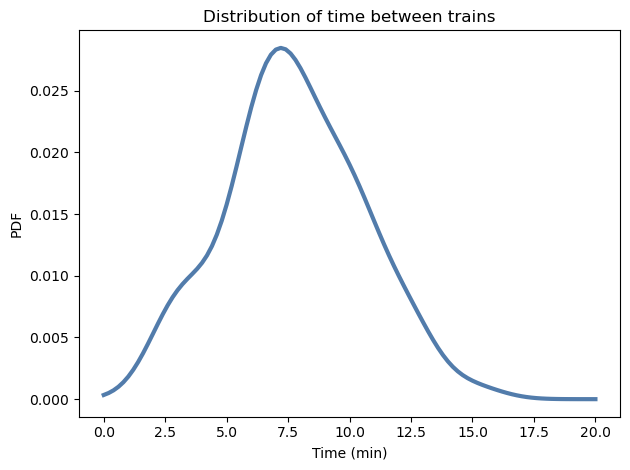

```python
pmf_z.plot()

decorate(xlabel='Time (min)', ylabel='PDF', title='Distribution of time between trains')
```

### 갱신

#### 플랫폼에 10명의 승객이 있는 것을 보았다고 가정했을 때, 대기 시간의 분포는?

- 무작위 도착(나)에 의해 관찰된 열차 간격 시간의 분포를 도출
- 다음 승객 수에 따른 대기 시간 분포를 도출

```python
likelihood = pmf_z.qs
```

```python
posterior_z = pmf_z * pmf_z.qs
posterior_z.normalize()
```

```
7.772927524715933
```

#### 열차간격의 사후분포

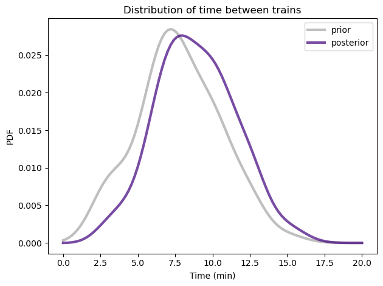

```python
pmf_z.plot(label='prior', color='C5')
posterior_z.plot(label='posterior', color='C4')

decorate(xlabel='Time (min)', ylabel='PDF', title='Distribution of time between trains')
```

- 사전 평균은 약 7.8분, 후방 평균은 약 8.9분

```python
pmf_z.mean(), posterior_z.mean()
```

```
(7.772927524715933, 8.89677416786441)
```

#### 레드 라인 일정에는 열차가 피크 시간대에 9분 간격으로 운행된다고 보고되어 있으며, 이는 사후 평균에 가깝고 사전 평균보다 높음

### 경과시간

- 경과 시간 `x` : **이전 열차의 도착과 승객의 도착 사이의 시간**
- 대기 시간 `y` : **승객의 도착과 다음 열차의 도착 사이의 시간**

  열차 간격 `z`는

```
z = x + y.
```

#### 이며 `z`의 분포는 `x`와 `y`의 혼합분포

#### 각 열차 간격 `z`값 마다, 경과 시간 `x`는 균등분포를 따름

- 예) 열차 간격이 0.6분이라면,

  경과시간이 [0분, 0.2분, 0.4분, 0.6분]일 확률은 동일

```python
from empiricaldist import Pmf
```

```python
def make_elapsed_dist(gap, qs):

    qs = qs[qs <= gap]
    n = len(qs)
    return Pmf(1/n, qs)
```

```python
qs = posterior_z.qs
pmf_seq = [make_elapsed_dist(gap, qs) for gap in qs]
```

```python
pmf_seq[3]
```

|  | probs |
| --- | --- |
| 0.0 | 0.25 |
| 0.2 | 0.25 |
| 0.4 | 0.25 |
| 0.6 | 0.25 |

- 경과시간 `x`에 대하여 0분에서 20분까지 균등분포

```python
pmf_seq[-1]
```

|  | probs |
| --- | --- |
| 0.0 | 0.009901 |
| 0.2 | 0.009901 |
| 0.4 | 0.009901 |
| 0.6 | 0.009901 |
| 0.8 | 0.009901 |
| ... | ... |
| 19.2 | 0.009901 |
| 19.4 | 0.009901 |
| 19.6 | 0.009901 |
| 19.8 | 0.009901 |
| 20.0 | 0.009901 |

101 rows × 1 columns

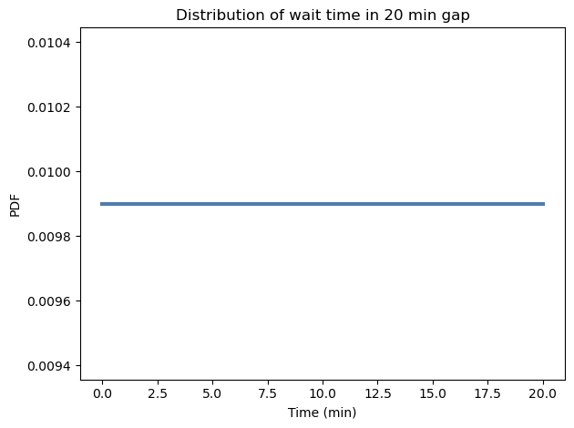

```python
pmf_seq[-1].plot()

decorate(xlabel='Time (min)', ylabel='PDF', title='Distribution of wait time in 20 min gap')
```

#### 위 각 열차 간격 `z`별, 경과 시간 `x`의 사전균등분포와, `z`의 사후분포간 합분포를 통하여 갱신 $\rightarrow$ 경과 시간 `x`의 사후분포

```python
from utils import make_mixture
```

```python
pmf_x = make_mixture(posterior_z, pmf_seq)
```

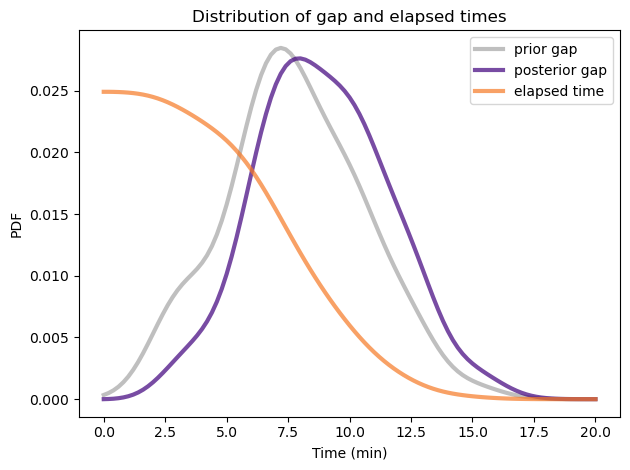

```python
pmf_z.plot(label='prior gap', color='C5')
posterior_z.plot(label='posterior gap', color='C4')
pmf_x.plot(label='elapsed time', color='C1')

decorate(xlabel='Time (min)', ylabel='PDF', title='Distribution of gap and elapsed times')
```

```python
posterior_z.mean(), pmf_x.mean()
```

```
(8.89677416786441, 4.448387083932206)
```

#### 평균 경과 시간은 4.4분으로, 열차 간격 사후평균의 절반입니다

#### 따라서, 평균적으로 열차 간격의 중간에, 승객이 역에 도착할 것이라는 예상 가능

### 승객수 예측

#### 승객이 언제든지 도착할 확률이 동일하고, 평균적으로 분당 2명이 도착한다고 가정

- 도착 승객수는 매개변수 $λ=2$를 가지는 포아송 분포를 따름

#### 이전 열차가 지난 후 `x`분의 경과 시간이 지났다면, 도착한 승객수는 $\lambda$`x`를 매개변수로 가지는 포아송 분포를 따름

#### 10명의 승객이 `x`분의 경과 시간이 지나고 도착해 있을 때의 가능도

```python
from scipy.stats import poisson
```

```python
lam = 2
num_passengers = 10
likelihood = poisson(lam * pmf_x.qs).pmf(num_passengers)
```

#### `x`의 사후분포 계산

```python
posterior_x = pmf_x * likelihood
posterior_x.normalize()
```

```
0.04757676716097805
```

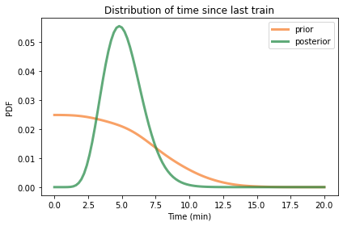

```python
pmf_x.plot(label='prior', color='C1')
posterior_x.plot(label='posterior', color='C2')

decorate(xlabel='Time (min)', ylabel='PDF', title='Distribution of time since last train')
```

#### 승객 수로 볼 때 막차로부터 약 5분 정도 지난 것으로 추정

```python
pmf_x.mean(), posterior_x.mean()
```

```
(4.448387083932206, 5.1439350761797495)
```

### 대기시간

```
z = x + y
```

```
y = z - x
```

#### `z`와 `x`의 사후분포로 계산한 `y`의 사후분포는 일부 음수 값이 포함 되어 있기에, 이를 제거하고 다시 정규화

```python
posterior_y = Pmf.sub_dist(posterior_z, posterior_x)
```

```python
nonneg = (posterior_y.qs >= 0)
posterior_y = Pmf(posterior_y[nonneg])
posterior_y.normalize()
```

```
0.8900343090047254
```

#### `x`, `y`, `z` 사후분포의 CDF

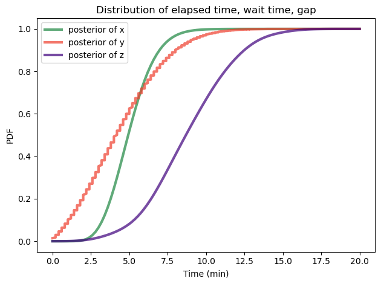

```python
posterior_x.make_cdf().plot(label='posterior of x', color='C2')
posterior_y.make_cdf().plot(label='posterior of y', color='C3')
posterior_z.make_cdf().plot(label='posterior of z', color='C4')

decorate(xlabel='Time (min)', ylabel='PDF', title='Distribution of elapsed time, wait time, gap')
```

### 의사결정

#### 플랫폼의 승객 수를 사용하여 대기 시간 분포를 예측할 수 있다면, 다음 열차를 기다리는 것을 멈추고 택시를 타야 하는가?

- 현재 관찰한 지연 시간은 15분이며, 더 긴 지연의 빈도를 정확하게 추정할 수 없음
- 1년 동안 레드라인으로 출퇴근했을 때 신호 문제, 정전, 다른 정류장에서 '경찰 활동'으로 인해 세 번의 긴 지연을 목격

  따라서 1년에 약 3번 정도 큰 지연이 발생하는 것으로 추정

  이러한 열차의 지연이, 대기하는 승객의 수에 영향을 미칠 수 있음 $\rightarrow$ **이러한 지연의 사례를 데이터에 포함**

#### **`z`의 사후분포에서 표본을 추출하고, 지연에 따른 30분, 40분, 50분이라는 긴 대기시간 데이터를 강제로 추가**

```python
sample = posterior_z.sample(260)
delays = [30, 40, 50]
augmented_sample = np.append(sample, delays)
```

#### 새로운 값이 추가된 새로운 사후분포

```python
qs = np.linspace(0, 60, 101)
augmented_posterior_z = kde_from_sample(augmented_sample, qs)
```

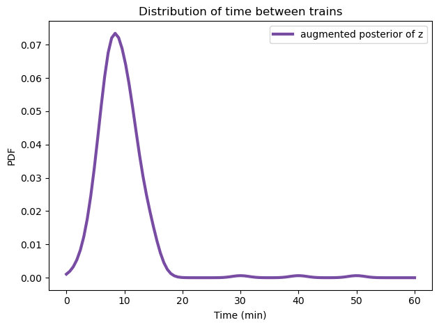

```python
augmented_posterior_z.plot(label='augmented posterior of z', color='C4')

decorate(xlabel='Time (min)', ylabel='PDF', title='Distribution of time between trains')
```

#### 지금 까지의 모든 `x`와 `y`의 사후분포 계산과정을 하나의 함수로

```python
qs = augmented_posterior_z.qs
pmf_seq = [make_elapsed_dist(gap, qs) for gap in qs]
pmf_x = make_mixture(augmented_posterior_z, pmf_seq)
lam = 2
num_passengers = 10

def compute_posterior_y(num_passengers):

    likelihood = poisson(lam * qs).pmf(num_passengers)
    posterior_x = pmf_x * likelihood
    posterior_x.normalize()

    posterior_y = Pmf.sub_dist(augmented_posterior_z, posterior_x)
    nonneg = (posterior_y.qs >= 0)
    posterior_y = Pmf(posterior_y[nonneg])
    posterior_y.normalize()

    return posterior_y
```

- **승객이 10명일 경우의 대기시간 `y` 사후분포**

```python
posterior_y = compute_posterior_y(10)
```

- **평균 대기 시간과 15분 이상 대기할 확률**

```python
posterior_y.mean()
```

```
5.006011527665594
```

```python
1 - posterior_y.make_cdf()(15)
```

```
0.013160204482796534
```

#### 승객 10명이 대기하는 것을 관찰했다면, 5분 조금 안 되는 시간을 기다릴 것으로 예상하고, 15분 이상 기다릴 확률은 약 1%

### 대기 승객수 범위 0 ~ 37명에 대한, `y`의 사후분포

```python
nums = np.arange(0, 37, 3)
posteriors = [compute_posterior_y(num) for num in nums]
```

#### 대기 승객 수에 따른 평균 대기 시간

```python
mean_wait = [posterior_y.mean() for posterior_y in posteriors]
```

```python
import matplotlib.pyplot as plt
```

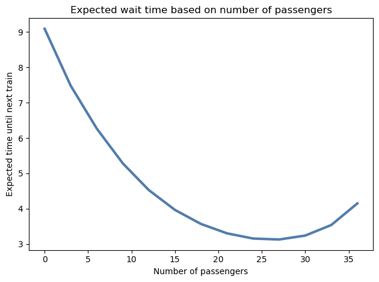

```python
plt.plot(nums, mean_wait)

decorate(xlabel='Number of passengers', ylabel='Expected time until next train', title='Expected wait time based on number of passengers')
```

#### 내가 역에 도착했을 때, 플랫폼에 승객이 없다면 나는 방금 기차를 놓친 것이라고 추론가능하며, 이 경우 예상 대기 시간은 9분

#### 승객이 많을수록 마지막 열차 이후 시간이 오래 지났고 열차가 곧 도착할 가능성이 높아짐

#### 그러나 플랫폼에 승객이 30명 이상이면, 지연 시간이 길어지고 예상 대기 시간도 늘어나기 시작

#### 대기 승객수에 따른, 대기 시간이 15분을 초과할 확률

```python
prob_late = [1 - posterior_y.make_cdf()(15) for posterior_y in posteriors]
```

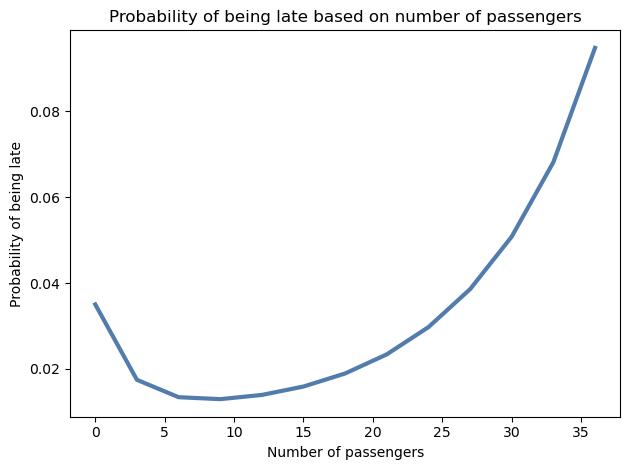

```python
plt.plot(nums, prob_late)

decorate(xlabel='Number of passengers', ylabel='Probability of being late', title='Probability of being late based on number of passengers')
```

#### 승객 수가 20명 미만인 경우, 시스템이 정상적으로 작동하고 있는 것으로 추론하므로 장시간 지연될 확률은 적음

#### 승객이 30명이라면 뭔가 잘못된 것으로 의심되어 지연 시간이 더 길어질 것으로 예상

### 따라서 승객이 30명 미만일 때까지는 다음 열차를 기다려야 하고, 승객이 더 많으면 열차가 아닌 택시를 탑승하는 것이 바람직

## 21.02. 백신 효과 추정

> 최근 백신 실험에서는 백신을 접종한 그룹 중 질병에 걸린 사람이 없어 백신 제조사에서는 효과가 100%라고 보고했다.
- 현실 세계에서는 100% 효과를 가지는 백신은 존재하지 않다.

  따라서 이 사례에서는 질병자 수가 0일 때 어떻게 효능을 추정할 수 있는지에 대한 질문이 제기

> ...SARS-CoV-2 감염의 사전 증거가 있거나 없는 12~15세 청소년을 대상으로 한 3상 시험에서 화이자-바이오엔테크(Pfizer-BioNTech) 코로나19 백신 BNT162b2는 100% 효능과 강력한 항체 반응을 입증했습니다...

보도자료에는 결과에 대한 다음과 같은 세부정보가 포함

> 이 임상시험에는 미국에서 12~15세 청소년 2,260명이 등록되었습니다. 해당 시험에서 위약군(n=1,129)에서는 18건의 코로나19 사례가 관찰됐으나, 백신 접종군(n=1,131)에서는 한 건도 관찰되지 않았다.

더 큰 규모의 임상시험에서는 백신 접종 그룹에서 최소한 한 건의 사례가 나올 것으로 예상

#### 하지만 아직 일어나지 않은 일의 빈도를 어떻게 추정할 수 있는가?

보도 자료에 보고된 데이터는 다음과 같다

```python
n_control = 1129
n_treatment = 1131

cases_control = 18
cases_treatment = 0
```

#### 백신의 효능을 평가하기 위해 각 그룹의 위험도를 개별적으로 계산

### 베타사전분포

#### 사전분포를 균등분포로 가정했을 시, 사후분포는 켤레분포에 의해 베타분포로 정의 되기에

```
alpha = cases + 1
beta = n - cases + 1
```

```python
from scipy.stats import beta
```

```python
def make_beta(n, cases):
    return beta(cases+1, n-cases+1)
```

#### 통제군에 대한 사후분포

```python
dist_control = make_beta(n_control, cases_control)
dist_control.mean() * 100
```

```
1.6799292661361624
```

- 사후평균은 관측값과 유사

```python
cases_control / n_control * 100
```

```
1.5943312666076175
```

#### 치료군에 대한 사후분포

```python
dist_treatment = make_beta(n_treatment, cases_treatment)
dist_treatment.mean() * 100
```

```
0.088261253309797
```

#### 두 개의 사후 분포에 대한 이산 근사치

```python
import numpy as np
from empiricaldist import Pmf
```

```python
def make_pmf(dist):

    qs = np.linspace(8e-6, 0.03, 1000)
    ps = dist.pdf(qs)
    pmf = Pmf(ps, qs)
    pmf.normalize()
    return pmf
```

```python
pmf_control = make_pmf(dist_control).mul_dist(100)
pmf_treatment = make_pmf(dist_treatment).mul_dist(100)
```

```python
import matplotlib.pyplot as plt
```

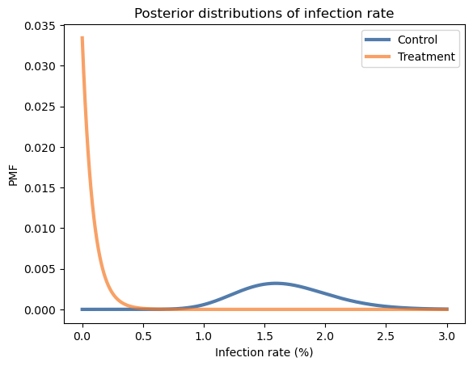

```python
pmf_control.plot(label='Control')
pmf_treatment.plot(label='Treatment')

plt.xlabel('Infection rate (%)')
plt.ylabel('PMF')
plt.title('Posterior distributions of infection rate')
plt.legend();
```

### 백신 효과 계산

#### 두 사후분포를 통하여, 위험비 RR의 분포를 계산

#### 이후, 백신의 효과를 계산 (1-RR)

#### 값이 높을수록 확률이 매우 낮기 때문에, 백신이 효과적이라고 확신

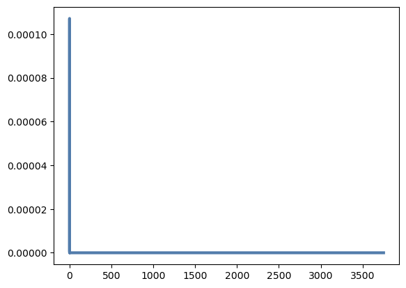

```python
pmf_ratio = pmf_treatment.div_dist(pmf_control)

pmf_ratio.plot()
plt.show()
```

#### 위험 비율의 CDF

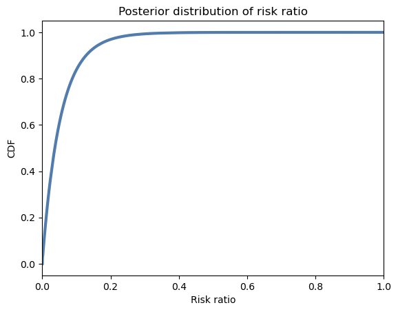

```python
pmf_ratio.make_cdf().plot()
plt.xlim([0, 1])

plt.xlabel('Risk ratio')
plt.ylabel('CDF')
plt.title('Posterior distribution of risk ratio');
```

#### 백신 효과의 분포를 계산하기 위해 1-RR 분포를 계산

```python
efficacy = Pmf.from_seq(1).sub_dist(pmf_ratio)
```

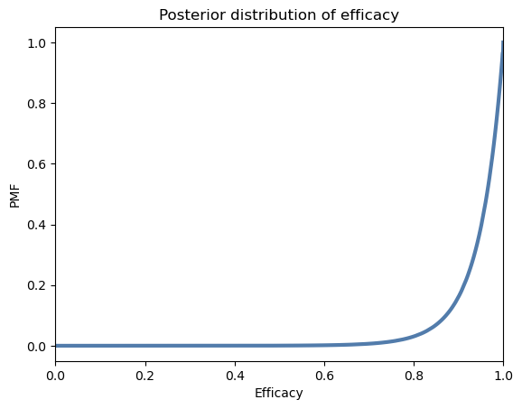

```python
efficacy.make_cdf().plot()
plt.xlim([0, 1])

plt.xlabel('Efficacy')
plt.ylabel('PMF')
plt.title('Posterior distribution of efficacy');
```

```python
efficacy.mean()
```

```
0.9449759891115062
```

```python
efficacy.credible_interval(0.95)
```

```
array([0.78696377, 0.99943336])
```